# AirBnb Milan - R Notebook

```r
#install.packages("dplyr")
#install.packages("tidyr")
#install.packages("ggplot2")

library(dplyr)
library(tidyr)
library(ggplot2)
```

Cargar el archivo “Airbnb_Milan.csv” como dataframe.

```r
df <- read.csv("Airbnb_Milan.csv")
head(df,10)
```

```
##     X     id host_id host_location host_response_time host_response_rate
## 1   1  73892  387110             1                  1                 57
## 2   2  74169  268127             1                  1                 57
## 3   3  77958  387110             1                  1                 57
## 4   4  93025  499743             1                  1                 57
## 5   5 132705  391011             1                  1                 57
## 6   6 141833  689467             1                  0                 29
## 7   7 233795 1224206             1                  1                 57
## 8   8 255104 1280906             1                  1                 57
## 9   9 271845 1422647             1                  1                 57
## 10 10 272886 1428106             1                  1                 57
##    host_is_superhost host_total_listings_count host_has_profile_pic
## 1                  0                         3                    1
## 2                  0                         1                    1
## 3                  0                         3                    1
```

[output cut: 150 more lines]

Crear un nuevo dataframe que contenga únicamente las siguientes columnas: “host_is_superhost”, “host_identity_verified”, “bathrooms”, “bedrooms”, “daily_price”, “security_deposit”, “minimum_nights”, “number_of_reviews”, “review_scores_rating”

```r
df <- subset(df, select=c("host_is_superhost",
                          "host_identity_verified",
                          "bathrooms",
                          "bedrooms",
                          "daily_price",
                          "security_deposit",
                          "minimum_nights",
                          "number_of_reviews",
                          "review_scores_rating"))
head(df,10)
```

```
##    host_is_superhost host_identity_verified bathrooms bedrooms daily_price
## 1                  0                      1         3        1          94
## 2                  0                      0         3        1         125
## 3                  0                      1         3        1         100
## 4                  0                      0         3        1         120
## 5                  1                      0         3        0          70
## 6                  0                      1         3        1         200
## 7                  1                      0         5        1         700
## 8                  0                      0         3        1         250
## 9                  0                      1         3        1         100
## 10                 0                      0         3        1         280
##    security_deposit minimum_nights number_of_reviews review_scores_rating
## 1                 1              2                84                   94
## 2                31              2                 3                  100
## 3                 1              2                70                   97
## 4                48              2                57                   97
## 5                13             30                44                   90
## 6                48             15                79                   98
## 7                 1              1                72                   96
## 8                73              1               126                   98
## 9                13              1               377                   94
## 10                1              1                22                   95
```

Cambiar los factores de la variable “host_is_superhost” de 0, 1 a: “SI” y, “NO”. (investigar la función recode).

```r
df$host_is_superhost <- recode(df$host_is_superhost, `0` = "NO", `1` = "SI")
df$host_is_superhost <- as.factor(df$host_is_superhost)
head(df,10)
```

```
##    host_is_superhost host_identity_verified bathrooms bedrooms daily_price
## 1                 NO                      1         3        1          94
## 2                 NO                      0         3        1         125
## 3                 NO                      1         3        1         100
## 4                 NO                      0         3        1         120
## 5                 SI                      0         3        0          70
## 6                 NO                      1         3        1         200
## 7                 SI                      0         5        1         700
## 8                 NO                      0         3        1         250
## 9                 NO                      1         3        1         100
## 10                NO                      0         3        1         280
##    security_deposit minimum_nights number_of_reviews review_scores_rating
## 1                 1              2                84                   94
## 2                31              2                 3                  100
## 3                 1              2                70                   97
## 4                48              2                57                   97
## 5                13             30                44                   90
## 6                48             15                79                   98
## 7                 1              1                72                   96
## 8                73              1               126                   98
## 9                13              1               377                   94
## 10                1              1                22                   95
```

```r
class(df$host_is_superhost)
```

```
## [1] "factor"
```

Cambiar los factores de la variable “host_identity_verified” de 0, 1 a: “VERIFICA” y “NO VERIFICA”.

```r
df$host_identity_verified <- recode(df$host_identity_verified, `0` = "NO VERIFICA", `1` = "VERIFICA")
df$host_identity_verified <- as.factor(df$host_identity_verified)
head(df,10)
```

```
##    host_is_superhost host_identity_verified bathrooms bedrooms daily_price
## 1                 NO               VERIFICA         3        1          94
## 2                 NO            NO VERIFICA         3        1         125
## 3                 NO               VERIFICA         3        1         100
## 4                 NO            NO VERIFICA         3        1         120
## 5                 SI            NO VERIFICA         3        0          70
## 6                 NO               VERIFICA         3        1         200
## 7                 SI            NO VERIFICA         5        1         700
## 8                 NO            NO VERIFICA         3        1         250
## 9                 NO               VERIFICA         3        1         100
## 10                NO            NO VERIFICA         3        1         280
##    security_deposit minimum_nights number_of_reviews review_scores_rating
## 1                 1              2                84                   94
## 2                31              2                 3                  100
## 3                 1              2                70                   97
## 4                48              2                57                   97
## 5                13             30                44                   90
## 6                48             15                79                   98
## 7                 1              1                72                   96
## 8                73              1               126                   98
## 9                13              1               377                   94
## 10                1              1                22                   95
```

```r
class(df$host_identity_verified)
```

```
## [1] "factor"
```

Mostrar un resumen estadístico de los datos.

```r
summary(df)
```

```
##  host_is_superhost host_identity_verified   bathrooms
##  NO:6629           NO VERIFICA:5302       Min.   : 1.000
##  SI:2693           VERIFICA   :4020       1st Qu.: 3.000
##                                           Median : 3.000
##                                           Mean   : 3.357
##                                           3rd Qu.: 3.000
##                                           Max.   :17.000
##     bedrooms       daily_price     security_deposit minimum_nights
##  Min.   : 0.000   Min.   :  10.0   Min.   :  1.00   Min.   :  1.000
##  1st Qu.: 1.000   1st Qu.:  59.0   1st Qu.:  1.00   1st Qu.:  1.000
##  Median : 1.000   Median :  75.0   Median :  1.00   Median :  2.000
##  Mean   : 1.218   Mean   : 103.7   Mean   : 21.71   Mean   :  3.205
##  3rd Qu.: 2.000   3rd Qu.: 107.0   3rd Qu.: 48.00   3rd Qu.:  2.000
##  Max.   :10.000   Max.   :3000.0   Max.   :143.00   Max.   :365.000
##  number_of_reviews review_scores_rating
##  Min.   :  1.00    Min.   : 20.00
##  1st Qu.:  4.00    1st Qu.: 90.00
##  Median : 14.00    Median : 95.00
##  Mean   : 39.64    Mean   : 93.15
##  3rd Qu.: 44.00    3rd Qu.: 99.00
##  Max.   :791.00    Max.   :100.00
```

Filtrar el dataset por apartamentos cuyo mínimo de noches sea igual o menor que siete.

```r
df_filtrado <- filter(df, minimum_nights<=7)
head(df_filtrado,10)
```

```
##    host_is_superhost host_identity_verified bathrooms bedrooms daily_price
## 1                 NO               VERIFICA         3        1          94
## 2                 NO            NO VERIFICA         3        1         125
## 3                 NO               VERIFICA         3        1         100
## 4                 NO            NO VERIFICA         3        1         120
## 5                 SI            NO VERIFICA         5        1         700
## 6                 NO            NO VERIFICA         3        1         250
## 7                 NO               VERIFICA         3        1         100
## 8                 NO            NO VERIFICA         3        1         280
## 9                 NO            NO VERIFICA         3        1         320
## 10                NO            NO VERIFICA         3        1         240
##    security_deposit minimum_nights number_of_reviews review_scores_rating
## 1                 1              2                84                   94
## 2                31              2                 3                  100
## 3                 1              2                70                   97
## 4                48              2                57                   97
## 5                 1              1                72                   96
## 6                73              1               126                   98
## 7                13              1               377                   94
## 8                 1              1                22                   95
## 9                 1              1                31                   95
## 10                1              1                 1                   40
```

¿Cuál es el precio medio por día de una habitación en función de si el anfitrión tiene verificado o no su perfil?

```r
df %>% group_by(host_identity_verified) %>% summarise(precio_medio=mean(daily_price))
```

```
## # A tibble: 2 x 2
##   host_identity_verified precio_medio
##   <fct>                         <dbl>
## 1 NO VERIFICA                    104.
## 2 VERIFICA                       104.
```

Quién tiene más número de reseñas, ¿un super host o no super host?

```r
df %>% group_by(host_is_superhost) %>% summarise(number_of_reviews=n())
```

```
## # A tibble: 2 x 2
##   host_is_superhost number_of_reviews
##   <fct>                         <int>
## 1 NO                             6629
## 2 SI                             2693
```

Sobre la estadística anterior ¿quién tiene la puntuación media más alta?

```r
df %>% group_by(host_is_superhost) %>% summarise(number_of_reviews=n(), review_scores_rating=mean(review_scores_rating))
```

```
## # A tibble: 2 x 3
##   host_is_superhost number_of_reviews review_scores_rating
##   <fct>                         <int>                <dbl>
## 1 NO                             6629                 91.6
## 2 SI                             2693                 96.9
```

Crea un vector categórico llamado “CATEGORÍA”, en función de que, si para la puntuación de las reseñas tiene de 0 a 49, sea “NO ACONSEJABLE”; de 50 a 75 sea “ESTÁNDAR”; y de 76 a 100 sea “TOP”.

```r
df <- mutate(df, categoria = case_when(
        between(df$review_scores_rating, 0, 49) ~ "NO ACONSEJABLE",
        between(df$review_scores_rating, 50, 75) ~ "ESTÁNDAR",
        between(df$review_scores_rating, 76, 100) ~ "TOP"
      ))

head(df,10)
```

```
##    host_is_superhost host_identity_verified bathrooms bedrooms daily_price
## 1                 NO               VERIFICA         3        1          94
## 2                 NO            NO VERIFICA         3        1         125
## 3                 NO               VERIFICA         3        1         100
## 4                 NO            NO VERIFICA         3        1         120
## 5                 SI            NO VERIFICA         3        0          70
## 6                 NO               VERIFICA         3        1         200
## 7                 SI            NO VERIFICA         5        1         700
## 8                 NO            NO VERIFICA         3        1         250
## 9                 NO               VERIFICA         3        1         100
## 10                NO            NO VERIFICA         3        1         280
##    security_deposit minimum_nights number_of_reviews review_scores_rating
## 1                 1              2                84                   94
## 2                31              2                 3                  100
## 3                 1              2                70                   97
```

[output cut: 18 more lines]

Mostrar las frecuencias de la variable CATEGORÍA.

```r
table(df$categoria)
```

```
##
##       ESTÁNDAR NO ACONSEJABLE            TOP
##            263             42           9017
```

Obtener el histograma del precio por día.

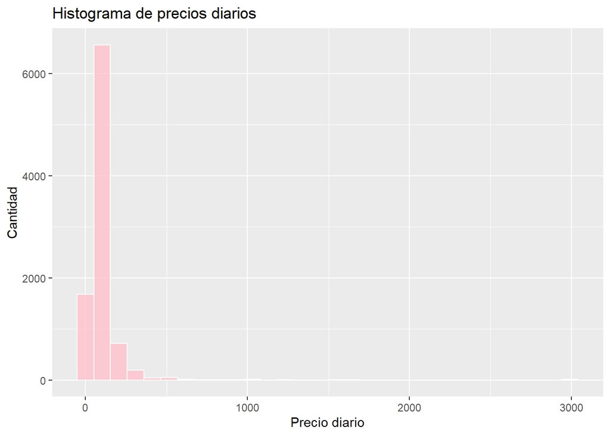

```r
ggplot(df) +
geom_histogram(
  mapping = aes(daily_price),
  colour = "white",
  fill = "pink",
  alpha = 0.8
) + ggtitle("Histograma de precios diarios") +
xlab("Precio diario") +
ylab("Cantidad")
```

Estudiar la relación entre los dormitorios y baños de forma gráfica.

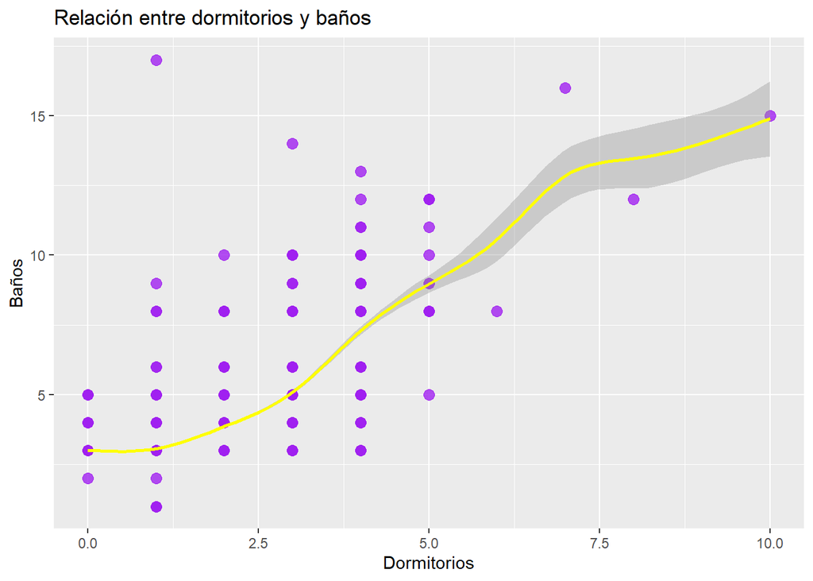

```r
ggplot(df) +
geom_point(
  mapping = aes(x=bedrooms, y=bathrooms),
  colour = "purple",
  size = 3,
  alpha = 0.8
) + ggtitle("Relación entre dormitorios y baños") +
xlab("Dormitorios") +
ylab("Baños") +
geom_smooth(aes(bedrooms, bathrooms),
            colour = "yellow")
```

[figure not shown]

```r
ggplot(df) +
geom_histogram(
  mapping = aes(daily_price, fill = host_identity_verified),
  colour = "white",
  alpha = 0.8
) + ggtitle("Histograma de reseñas por verificación de usuario") +
xlab("Número de reseñas") +
ylab("Cantidad") +
scale_fill_discrete(name = "Tipo de usuario")
```

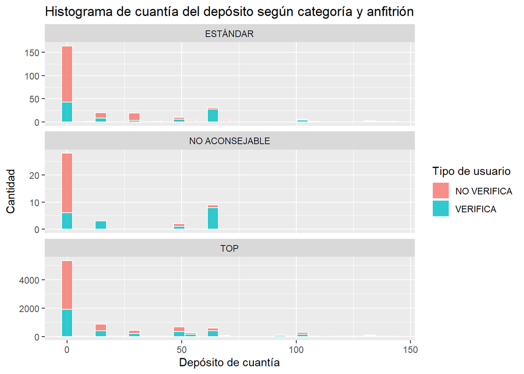

```r
ggplot(df) +
geom_histogram(
  mapping = aes(security_deposit, fill = host_identity_verified),
  colour = "white",
  alpha = 0.8
) + facet_wrap(~categoria, ncol = 1, scales = "free_y") +
ggtitle("Histograma de cuantía del depósito según categoría y anfitrión") +
xlab("Depósito de cuantía") +
ylab("Cantidad") +
scale_fill_discrete(name = "Tipo de usuario")
```